# Titanic Data Exploratory Analysis

In this project, I am analyzing the titanic dataset which has the demographics information for 891 (out of 2224) passengers on board the Titanic ship. The descriptions for the column names in the file (titanic-data.csv) can be seen from the [Kaggle website](https://www.kaggle.com/c/titanic/data). I am breaking down the analysis into four steps-

- **Data Extraction**
- **Data Cleaning**
- **Data Visualization**
- **Inferential Statistics**

**Data Extraction**: I am importing the python modules which will be used in the project and creating a dataframe for the titanic data from the csv file.

```python
# Imports pandas,numpy, matplotlib, seaborn, unicodecsv
import matplotlib.pyplot as plt
import numpy as np
import pandas as pd
import seaborn as sns
import unicodecsv
from scipy import stats

sns.set(font_scale=1.5)

% matplotlib inline

# Create a dataframe for the titanic data from the csv file and look at the data values
titanic_df = pd.read_csv('titanic-data.csv')

# Look at the first 20 rows
titanic_df.head(10)
```

|  | PassengerId | Survived | Pclass | Name | Sex | Age | SibSp | Parch | Ticket | Fare | Cabin | Embarked |
| --- | --- | --- | --- | --- | --- | --- | --- | --- | --- | --- | --- | --- |
| 0 | 1 | 0 | 3 | Braund, Mr. Owen Harris | male | 22.0 | 1 | 0 | A/5 21171 | 7.2500 | NaN | S |
| 1 | 2 | 1 | 1 | Cumings, Mrs. John Bradley (Florence Briggs Th... | female | 38.0 | 1 | 0 | PC 17599 | 71.2833 | C85 | C |
| 2 | 3 | 1 | 3 | Heikkinen, Miss. Laina | female | 26.0 | 0 | 0 | STON/O2. 3101282 | 7.9250 | NaN | S |
| 3 | 4 | 1 | 1 | Futrelle, Mrs. Jacques Heath (Lily May Peel) | female | 35.0 | 1 | 0 | 113803 | 53.1000 | C123 | S |
| 4 | 5 | 0 | 3 | Allen, Mr. William Henry | male | 35.0 | 0 | 0 | 373450 | 8.0500 | NaN | S |
| 5 | 6 | 0 | 3 | Moran, Mr. James | male | NaN | 0 | 0 | 330877 | 8.4583 | NaN | Q |
| 6 | 7 | 0 | 1 | McCarthy, Mr. Timothy J | male | 54.0 | 0 | 0 | 17463 | 51.8625 | E46 | S |
| 7 | 8 | 0 | 3 | Palsson, Master. Gosta Leonard | male | 2.0 | 3 | 1 | 349909 | 21.0750 | NaN | S |
| 8 | 9 | 1 | 3 | Johnson, Mrs. Oscar W (Elisabeth Vilhelmina Berg) | female | 27.0 | 0 | 2 | 347742 | 11.1333 | NaN | S |
| 9 | 10 | 1 | 2 | Nasser, Mrs. Nicholas (Adele Achem) | female | 14.0 | 1 | 0 | 237736 | 30.0708 | NaN | C |

**Data Cleaning**: Next, I am handling the missing values. For the "Age" column, I am filling in NaN values with the median age for the group. For the "Embarked" column, I am filling in the missing values with the most common value "S" (for Southampton).

```python
# Fill in NaN 'Age' values with median
titanic_df['Age'] = titanic_df['Age'].fillna(titanic_df['Age'].median())

#Fill in NaN 'Embarked" values with mode
titanic_df['Embarked'] = titanic_df['Embarked'].fillna('S')
```

**Data Visualization**: I am starting by exploring the question: **What factors affect the survival rates among the passengers?**

Firstly, I am exploring the relationship between survival rate and factors such as gender, ticket fare, the number of family members on board, and embarkment point individually.

```python
# Gender
# Look at values for survival by gender in a table
table_gender = pd.crosstab(index = titanic_df['Survived'], columns = titanic_df['Sex'], margins = True)
table_gender.index = ['Not survived','Survived', 'Total']
table_gender
```

| Sex | female | male | All |
| --- | --- | --- | --- |
| Not survived | 81 | 468 | 549 |
| Survived | 233 | 109 | 342 |
| Total | 314 | 577 | 891 |

```python
# Table with survival rates by gender
table_gender_perc = pd.crosstab(index = titanic_df['Survived'], columns = titanic_df['Sex'], margins = True, normalize = True)
table_gender_perc
```

| Sex Survived | female | male | All |
| --- | --- | --- | --- |
| 0 | 0.090909 | 0.525253 | 0.616162 |
| 1 | 0.261504 | 0.122334 | 0.383838 |
| All | 0.352413 | 0.647587 | 1.000000 |

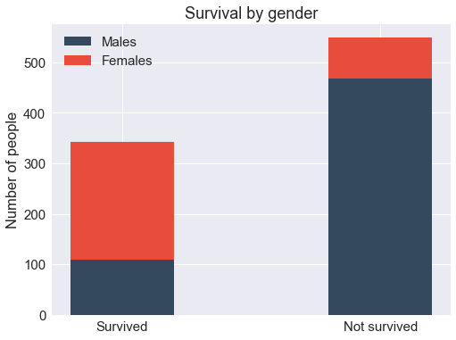

```python
# Create dataframes for males and females

female_df = titanic_df[titanic_df['Sex'] == 'female']
male_df = titanic_df[titanic_df['Sex'] == 'male']

# Create data frames by survival and save the values of males/females survived in a numpy array

female_survived = female_df[female_df['Survived'] == 1]['Survived']
male_survived = male_df[male_df['Survived'] == 1]['Survived']

female_survival_num = np.array([len(female_survived.index), len(female_df.index)-len(female_survived.index)])
male_survival_num = np.array([len(male_survived.index), len(male_df.index)-len(male_survived.index)])

# Plot the number of people who survived by gender

n = len(male_survival_num)
ind = np.arange(n)
width = 0.4
fig, ax = plt.subplots()
fig.set_size_inches(8, 6)
p1 = plt.bar(ind, male_survival_num, width, label='Males', color='#34495e')
p2 = plt.bar(ind, female_survival_num, width, bottom=male_survival_num, label='Females', color='#e74c3c')

# Label x and y axis, add title and legend for plot

ax.set_ylabel('Number of people')
ax.set_title('Survival by gender')
ax.legend()
ax.set_xticks(ind)
ax.set_xticklabels(['Survived', 'Not survived'])
```

From the plots and tables for survival rates by gender, we can see a strong correlation between gender and survival rate. Females had higher survival rates than males.

Next, I am exploring the relationship between the ticket fare and survival rate. I am looking at the median fare amount for people who survived and died.

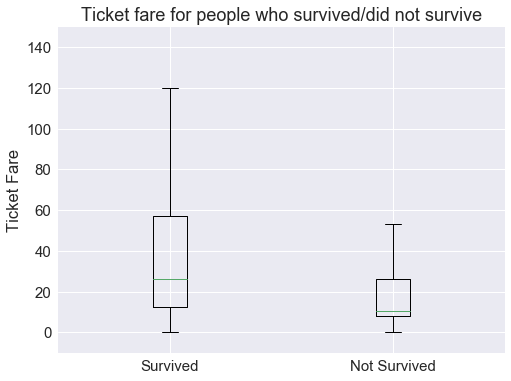

```python
# Create two dataframes for getting the fare amount of people who survived and did not survive

not_survived_fare = titanic_df['Fare'][titanic_df['Survived'] == 0]
survived_fare = titanic_df['Fare'][titanic_df['Survived'] == 1]
fare = [survived_fare, not_survived_fare]

# Plot a boxplot
fig, ax = plt.subplots()
fig.set_size_inches(8, 6)
plt.boxplot(fare)

# Add x-axis
ax.set_xticks(range(1, 3))
ax.set_xticklabels(['Survived', 'Not Survived'])

# Add y-axis
ax.set_ylim([-10, 150])
ax.set_title('Ticket fare for people who survived/did not survive',fontsize=18)
ax.set_ylabel('Ticket Fare')
```

From the boxplot for fare values, we can see that the median fare for the group of people who survived is higher than the group who did not survive.

Further, I am looking at the relationship between the number of family members aboard and the survival rate. For the analysis, I am combining the "SibSp" and "Parch" columns which give the number of siblings/spouses and parents/children respectively. The analysis might give some insight into which group of people were more likely to survive - the ones travelling alone or with family.

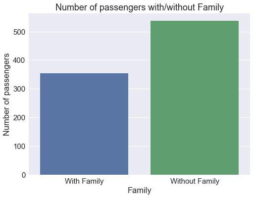

```python
# Return whether the person has family aboard
def hasFamily(x, y):
    return 1 if x + y > 0 else 0

# Create a new column indicating if person has family members aboard
titanic_df['Family'] = np.vectorize(hasFamily)(titanic_df['SibSp'], titanic_df['Parch'])

# Plot the number of people with and without family
fig, ax = plt.subplots()
fig.set_size_inches(8, 6)
g = sns.countplot(x='Family', data=titanic_df, order=[True,False],ax=ax)
g.set_ylabel('Number of passengers')
g.set_xticklabels(['With Family', 'Without Family'])
g.axes.set_title('Number of passengers with/without Family')
```

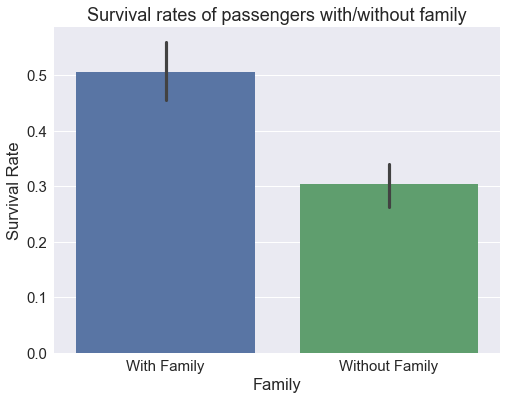

```python
# Plot to show the survival rate for people with and without family
fig, ax = plt.subplots()
fig.set_size_inches(8, 6)
g = sns.barplot(x='Family', y='Survived', data=titanic_df, order=[True,False],ax=ax)
g.set_ylabel('Survival Rate')
g.set_xticklabels(['With Family', 'Without Family'])
g.axes.set_title('Survival rates of passengers with/without family')
```

Next, I am looking at the relationship between the embarkment points and survival rate.

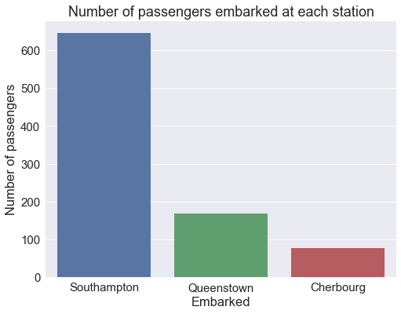

```python
# Plot the number of people embarked at each station
fig, ax = plt.subplots()
fig.set_size_inches(8, 6)
g = sns.countplot(x='Embarked', data=titanic_df,ax=ax)
g.set_ylabel('Number of passengers')
g.set_xticklabels(['Southampton','Queenstown','Cherbourg'])
g.axes.set_title('Number of passengers embarked at each station')
```

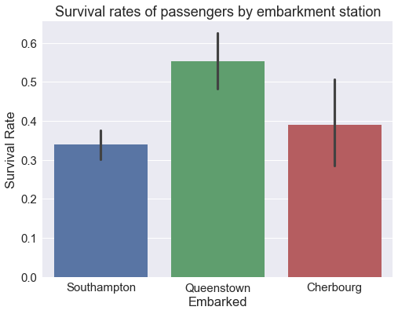

```python
# Plot to show the survival rate for people who embarked at each station
fig, ax = plt.subplots()
fig.set_size_inches(8, 6)
g = sns.barplot(x='Embarked', y='Survived', data=titanic_df,ax=ax)
g.set_ylabel('Survival Rate')
g.set_xticklabels(['Southampton','Queenstown','Cherbourg'])
g.axes.set_title('Survival rates of passengers by embarkment station')
```

Next, I am looking at how passenger class and gender might have relationship with survival rate.

```python
# Survival numbers by gender and p class
table_gen_class = pd.crosstab(index=titanic_df['Survived'], columns=[titanic_df['Sex'], titanic_df['Pclass']],
                              rownames=['Survived'], margins=True)
table_gen_class
```

| Sex Pclass Survived | female 1 | female 2 | female 3 | male 1 | male 2 | male 3 | All |
| --- | --- | --- | --- | --- | --- | --- | --- |
| 0 | 3 | 6 | 72 | 77 | 91 | 300 | 549 |
| 1 | 91 | 70 | 72 | 45 | 17 | 47 | 342 |
| All | 94 | 76 | 144 | 122 | 108 | 347 | 891 |

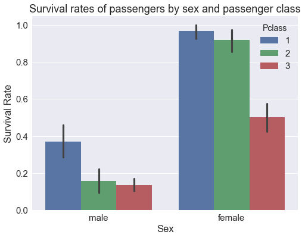

```python
# Survival rates by class and gender
fig, ax = plt.subplots()
fig.set_size_inches(8, 6)
g = sns.barplot(x='Sex', y='Survived', hue='Pclass', data=titanic_df,ax=ax)
g.axes.set_title('Survival rates of passengers by sex and passenger class')
g.set_ylabel('Survival Rate')
```

The barplot for survival rates by passenger class and gender shows that females in first class had above 90% survival rate. In contrast, females in third class had about 50% survival rate. First class male passengers had higher survival rate than second and third class males.

Next, I am exploring how the passenger class, gender and age relate to survival rates through violin plots.

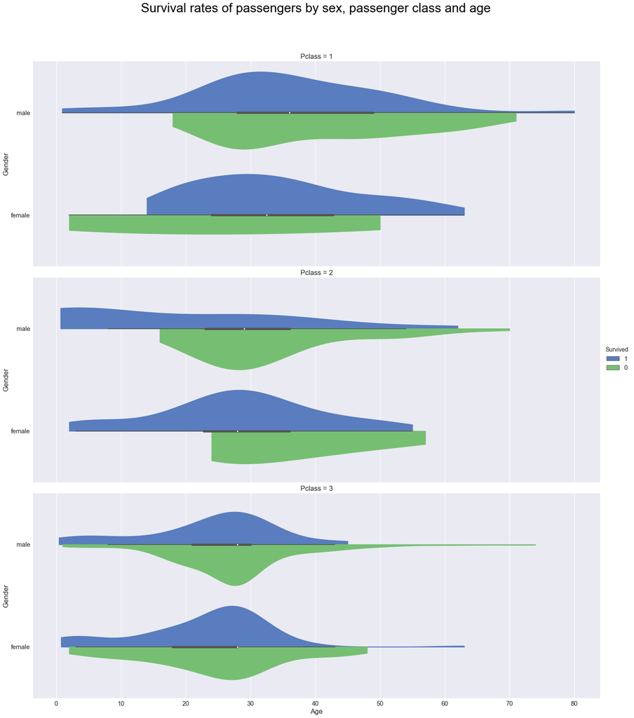

```python
# Violin plot for survival by pclass, gender and age
g = sns.factorplot(x='Age', y='Sex', row='Pclass', hue='Survived', hue_order=[1,0],
               data=titanic_df, kind='violin', split=True, size=8, aspect=2.5, cut=0, palette='muted')

g.set_axis_labels("Age", "Gender")
plt.subplots_adjust(top=0.9)
sns.plt.suptitle('Survival rates of passengers by sex, passenger class and age', fontsize=30, color = 'black')
```

The above violin plot aids in identifying overall trends in data. The plot shows that in the first and second class, almost all the males below the age 15 survived. Preferential treatment for children holds true for first and second class overall, but not for third class.

**Inferential Statistics**: Since we have seen a strong correlation between gender and survival rate, I am conducting a chi- squared test for the following hypothesis- Null Hypothesis: Gender and Survival are independent. Alternative Hypothesis: Gender and Survival are not independent.

```python
# Chi-Squared Tests
from scipy.stats import chi2_contingency
# Gender to Survivability
pivot = pd.pivot_table(data = titanic_df[['Survived', 'Sex']], index = 'Survived', columns = ['Sex'], aggfunc = len)
pivot
print pivot,"\n"

chi2, p_value, dof, expected = chi2_contingency(pivot)
print "Results of Chi-Squared test on gender to Survival."
print "Does gender have a significant effect on Survival?"
print "Chi-Squared Score = " + str(chi2)
print "Pvalue = " + str(p_value)
print "\n"
```

```
Sex       female  male
Survived
0             81   468
1            233   109

Results of Chi-Squared test on gender to Survival.
Does gender have a significant effect on Survival?
Chi-Squared Score = 260.717020167
Pvalue = 1.19735706278e-58
```

As we see, the results are significant for all reasonable alphas. We can reject the Null Hypothesis. So gender has a significant affect on the survival rates of the passengers with females having higher survival rates.

Next I am conducting a Chi-Squared test for the following hypothesis - Null Hypothesis: Passenger Class and Survived are independent. Alternative Hypothesis: Passenger Class and Survived are not independent.

```python
# Chi-Squared Tests
# Pclass to Survivability
pivot = pd.pivot_table(data = titanic_df[['Survived', 'Pclass']], index = 'Survived', columns = ['Pclass'], aggfunc = len)
pivot
print pivot,"\n"

chi2, p_value, dof, expected = chi2_contingency(pivot)
print "Results of Chi-Squared test on Passenger class to Survival."
print "Does Passenger class have a significant effect on Survival?"
print "Chi-Squared Score = " + str(chi2)
print "Pvalue = " + str(p_value)
print "\n"
```

```
Pclass      1   2    3
Survived
0          80  97  372
1         136  87  119

Results of Chi-Squared test on Passenger class to Survival.
Does Passenger class have a significant effect on Survival?
Chi-Squared Score = 102.888988757
Pvalue = 4.5492517113e-23
```

As we see, the results are significant for all reasonable alphas. Therefore, we can reject the Null Hypothesis.